PROCESAMIENTO DE IMÁGENES · UA – LCD – Año 2026

# Trabajo Práctico N.° 1

Informe técnico

Integrantes: Marcos Ziadi · Lautaro Sanfilippo · Bernardo Di Rienzo · Benjamin Miles Rouillón

## Problema 1 — Ecualización local del histograma

### La idea de fondo

Ecualizar el histograma de una imagen consiste en **redistribuir sus niveles de gris** para que queden lo más repartidos posible en todo el rango [0, 255], mejorando el contraste. Para ello se calcula el histograma (cuántos píxeles hay de cada intensidad), se obtiene su **función de distribución acumulada (CDF)** y se la usa como función de mapeo:

nuevo_valor = round( 255 × CDF(intensidad) )

### Por qué la ecualización global no alcanza

Si se ecualiza usando el histograma de *toda* la imagen (ecualización global), el fondo gris —que ocupa la mayor parte— domina el histograma. Los detalles escondidos están dentro de cuadros muy oscuros cuyos píxeles son una minoría, por lo que la transformación global casi no los modifica y siguen sin verse: en la figura, los cuadros negros quedan igual de negros.

### Cómo funciona la versión local

En lugar de un único histograma para toda la imagen, se define una **ventana M×N** que se desliza píxel a píxel. En cada posición:

- Se toma el vecindario M×N centrado en el píxel actual.
- Se calcula el histograma **solo de ese vecindario** y su CDF.
- Se mapea únicamente el **píxel central** con la fórmula de arriba.

Así el contraste se ajusta a las condiciones locales de cada zona: dentro de un cuadro oscuro, el histograma local está formado casi solo por valores oscuros, y la ecualización los "estira" hasta hacer visible el detalle oculto. Para centrar la ventana en los bordes se agrega un marco con `cv2.copyMakeBorder(..., BORDER_REPLICATE)`, que replica los píxeles del borde.

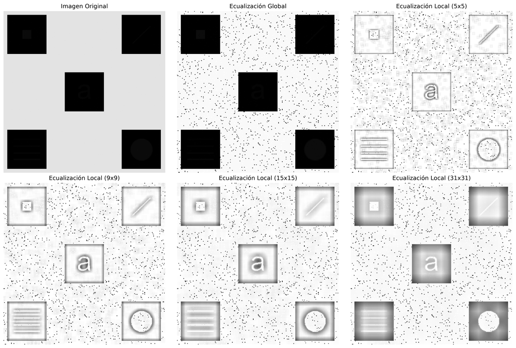

Figura 1 — Imagen original, ecualización global y ecualización local con distintos tamaños de ventana.

### Detalles escondidos encontrados

La ecualización local revela cinco detalles invisibles en la imagen original:

- Arriba-izquierda: un **cuadrado pequeño**.
- Arriba-derecha: una **línea diagonal**.
- Centro: la **letra "a"**.
- Abajo-izquierda: un grupo de **líneas horizontales**.
- Abajo-derecha: un **círculo**.

### Influencia del tamaño de la ventana

- **Ventana chica (5×5):** revela los detalles con mucho filo, pero **amplifica el ruido** (el histograma se calcula con muy pocos píxeles y cualquier variación se magnifica).
- **Ventana grande (31×31):** más suave y con menos ruido, pero se **pierde localidad**: los detalles se ven difusos y aparecen "halos" alrededor de los cuadros.
- **Ventanas intermedias (9×9 a 15×15):** el mejor compromiso entre nitidez y ruido.

En conclusión, el tamaño de ventana regula el balance entre **detalle/contraste local** (ventanas chicas) y **suavidad/robustez al ruido** (ventanas grandes).

## Problema 2 — Corrección de multiple choice

Se corrigen automáticamente exámenes de 10 preguntas con opciones A, B, C, D, tomando como **única entrada la imagen** del examen (sin coordenadas fijas). Respuestas correctas: `1.C 2.B 3.A 4.D 5.B 6.B 7.A 8.B 9.D 10.D`.

### Punto a — Corrección de las respuestas (OK / MAL)

**Detección de la grilla.** Se binariza la imagen y se cuentan los píxeles negros por columna y por fila. Donde hay una línea vertical, la columna acumula muchos píxeles negros; donde hay una horizontal, lo hace la fila. Esos picos ubican las líneas de la tabla.

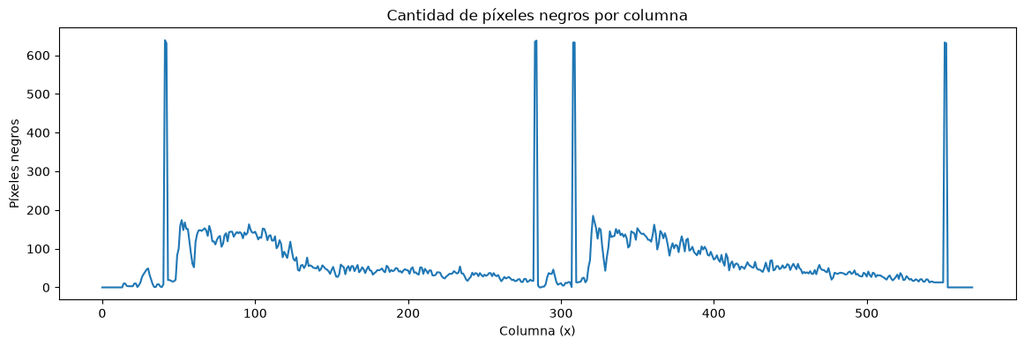

Figura 2 — Píxeles negros por columna (picos = líneas verticales).

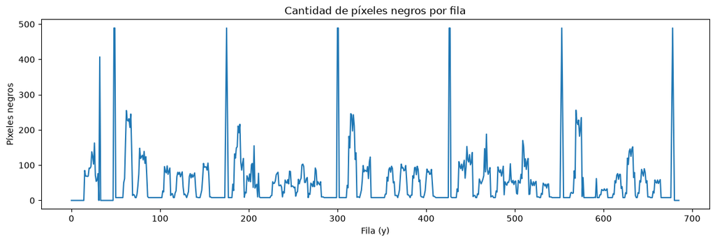

Figura 3 — Píxeles negros por fila (picos = líneas horizontales).

Con un umbral sobre esas proyecciones se obtienen los cortes que delimitan la tabla:

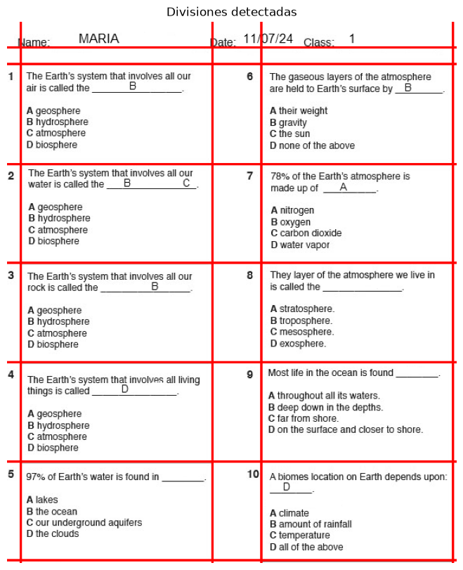

Figura 4 — Divisiones detectadas sobre el examen.

**Extracción de los cuadrantes.** Con esos cortes se recorta cada una de las 10 preguntas.

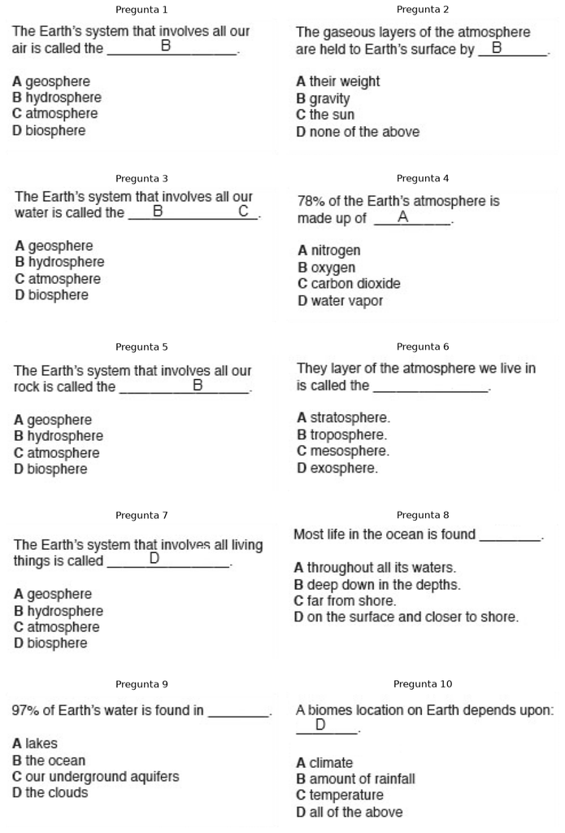

Figura 5 — Los 10 cuadrantes (preguntas) recortados.

**Detección de la respuesta.** En cada celda se detecta con un kernel la línea horizontal sobre la que el alumno escribe, y se recorta la región por encima de esa línea.

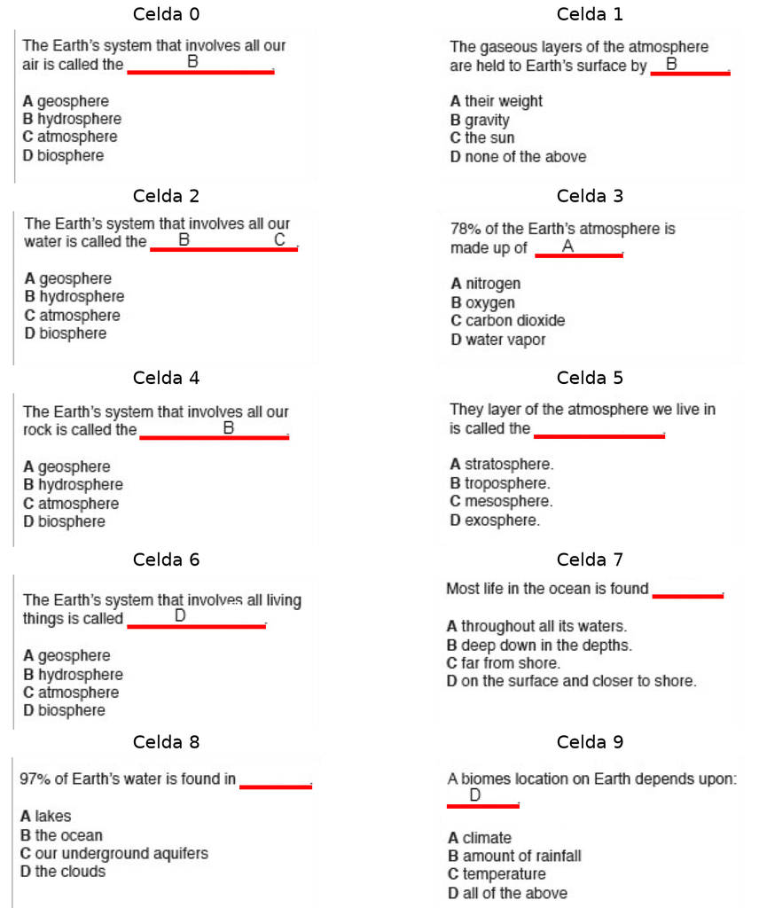

Figura 6 — Línea de respuesta detectada en cada celda.

Para decidir si hay respuesta:

- Si en el **30% inferior** de la región no hay ningún píxel negro → el alumno no respondió → incorrecta.
- Si hay al menos un píxel negro → se toma el **último renglón** (ahí siempre va la respuesta).

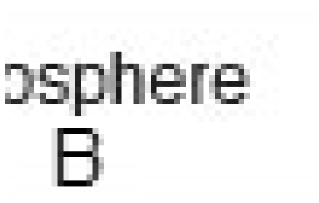

Se recorta para quedarse solo con la letra, sin píxeles de más.

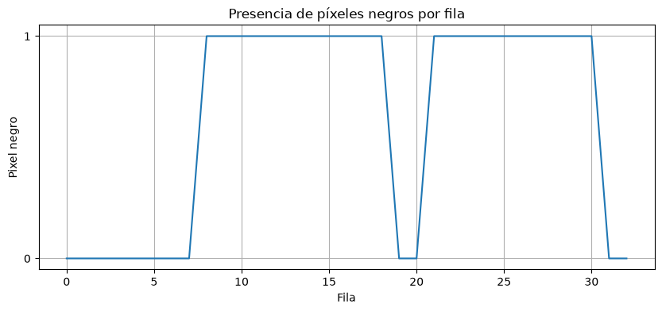

**Identificación de la letra (método de referencia).** Para saber qué letra es sin usar OCR, se usan **letras de referencia**: de un examen conocido se toman las cuatro opciones y se calcula un **descriptor** = cantidad de píxeles negros por fila (un "perfil" vertical de la letra). A una respuesta nueva se le calcula su descriptor y se lo compara con los de referencia por **distancia euclídea**, eligiendo el más cercano. Si la distancia mínima supera un umbral, se descarta como no válida (por ejemplo, doble marca). Finalmente se compara con la respuesta correcta y se informa OK/MAL.

### Punto b — Validación de los datos del encabezado

Se **reutiliza la técnica del punto a**: sumar píxeles negros por filas/columnas para ubicar las líneas. La primera línea horizontal larga marca el final del encabezado.

**Detección de los 3 campos.** Se buscan las tres líneas del encabezado como las componentes conectadas de mayor **relación ancho/alto** (líneas finas y largas). Ordenadas de izquierda a derecha son Name, Date y Class. El texto de cada campo es la región **por encima de su línea** y dentro de su rango horizontal (esto descarta la etiqueta impresa).

**Conteo sin reconocer letras.** Solo hay que **contar**. Se proyecta el texto sobre el eje horizontal: cada **corrida de columnas con tinta** es un carácter. Es más robusto que las componentes conectadas, porque una letra partida o la barra `/` de la fecha siguen siendo una única corrida. Las palabras se cuentan por los **espacios (gaps)** grandes entre caracteres.

Reglas: **Name** ≥ 2 palabras y ≤ 25 caracteres · **Date** = 8 caracteres, una palabra · **Class** = 1 carácter.

| Examen | Name | Date | Class |
| --- | --- | --- | --- |
| 1 | MAL (una palabra) | OK | OK |
| 2 | MAL (una palabra) | OK | OK |
| 3 | OK | OK | OK |
| 4 | OK | MAL (vacío) | OK |
| 5 | OK | OK | OK |

### Punto c — Evaluación de los exámenes resueltos

Se aplicó el algoritmo del punto a a los cinco exámenes. Resultado por pregunta:

|  | Ex.1 | Ex.2 | Ex.3 | Ex.4 | Ex.5 |
| --- | --- | --- | --- | --- | --- |
| Pregunta 1 | MAL | MAL | OK | MAL | OK |
| Pregunta 2 | MAL | OK | OK | MAL | OK |
| Pregunta 3 | MAL | MAL | OK | MAL | OK |
| Pregunta 4 | MAL | OK | OK | MAL | OK |
| Pregunta 5 | MAL | MAL | OK | MAL | OK |
| Pregunta 6 | MAL | OK | OK | MAL | OK |
| Pregunta 7 | MAL | OK | OK | MAL | OK |
| Pregunta 8 | MAL | MAL | OK | MAL | OK |
| Pregunta 9 | MAL | MAL | OK | MAL | OK |
| Pregunta 10 | MAL | OK | OK | MAL | OK |
| **Total** | **0/10** | **5/10** | **10/10** | **0/10** | **10/10** |

### Punto d — Imagen de aprobados y desaprobados

Se cuenta la cantidad de respuestas correctas de cada examen. Un alumno **aprueba con al menos 6 correctas**. Se genera una imagen que reúne el **crop del campo Name** de los cinco exámenes, con borde verde = APROBADO y borde rojo = DESAPROBADO, más el puntaje.

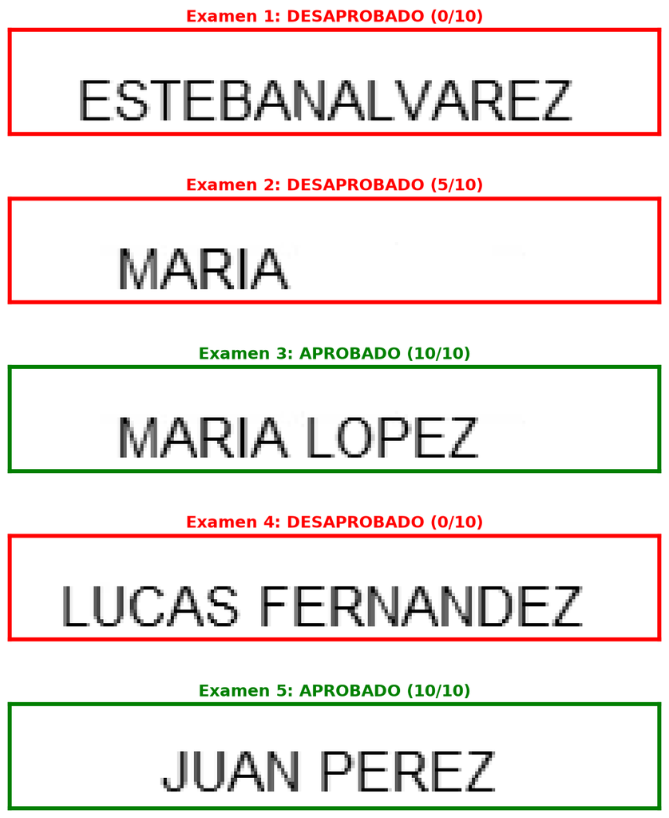

Figura 9 — Imagen de salida: aprobados (verde) y desaprobados (rojo).

| Examen | Alumno | Correctas | Estado |
| --- | --- | --- | --- |
| 1 | ESTEBANALVAREZ | 0/10 | DESAPROBADO |
| 2 | MARIA | 5/10 | DESAPROBADO |
| 3 | MARIA LOPEZ | 10/10 | APROBADO |
| 4 | LUCAS FERNANDEZ | 0/10 | DESAPROBADO |
| 5 | JUAN PEREZ | 10/10 | APROBADO |